# Assignment3_part1

Prinu Mathew, Qingwei Zhang, Jake Brewer

2023-02-01

## Assignment 3 Part 1

Perform latent class analysis of only the categorical variables for market segmentation using (function poLCA in package poLCA). Remember: the local optima problem is big for all the clustering and latent class methods. The data for analysis should only include the variables that you think have business relevance for market segmentation.

## Install packages.

```
install.packages("ggplot2")
install.packages("ggcorrplot")
install.packages("caret")
install.packages("poLCA")
install.packages("dplyr")
install.packages("Amelia")
install.packages("stringr")
install.packages("GGally")
```

## load the package

```r
library(ggplot2)
library(caret)
library(poLCA)
library(dplyr)
library(Amelia)
library(ggcorrplot)
library(stringr)
library(GGally)
```

## Step 0. Use csv data.

```r
GermanCredit <- read.table(
  "http://archive.ics.uci.edu/ml/machine-learning-databases/statlog/german/german.data",
  stringsAsFactors = TRUE
)

colnames(GermanCredit) <- c(
    "CheckingAccountStatus",
    "Duration",
    "CreditHistory",
    "Purpose",
    "Amount",
    "SavingsAccountBonds",
    "EmploymentDuration",
    "InstallmentRatePercentage",
    "Personal",
    "OtherDebtorsGuarantors",
    "ResidenceDuration",
    "Property",
    "Age",
    "OtherInstallmentPlans",
    "Housing",
    "NumberExistingCredits",
    "Job",
    "NumberPeopleMaintenance",
    "Telephone",
    "ForeignWorker",
    "Class"
)
```

## Step 1

Perform latent class analysis of only the categorical variables for market segmentation using (function poLCA in package poLCA). Remember: the local optima problem is big for all the clustering and latent class methods. The data for analysis should only include the variables that you think have business relevance for market segmentation.

```r
LCA_data <- GermanCredit[, c(1,3, 6, 7, 9, 12, 17)]


# convert to factor
LCA_data$CheckingAccountStatus <- as.factor(LCA_data$CheckingAccountStatus)
LCA_data$CreditHistory <- as.factor(LCA_data$CreditHistory)
LCA_data$SavingsAccountBonds <- as.factor(LCA_data$SavingsAccountBonds)
LCA_data$EmploymentDuration <- as.factor(LCA_data$EmploymentDuration)
LCA_data$Personal <- as.factor(LCA_data$Personal)
LCA_data$Property <- as.factor(LCA_data$Property)
LCA_data$Job <- as.factor(LCA_data$Job)


# convert to numeric
LCA_data$CheckingAccountStatus <- as.numeric(LCA_data$CheckingAccountStatus)
LCA_data$CreditHistory <- as.numeric(LCA_data$CreditHistory)
LCA_data$SavingsAccountBonds <- as.numeric(LCA_data$SavingsAccountBonds)
LCA_data$EmploymentDuration <- as.numeric(LCA_data$EmploymentDuration)
LCA_data$Personal <- as.numeric(LCA_data$Personal)
LCA_data$Property <- as.numeric(LCA_data$Property)
LCA_data$Job <- as.numeric(LCA_data$Job)
```

## correlations

A positive correlation indicates the extent to which those variables increase or decrease in parallel; a negative correlation indicates the extent to which one variable increases as the other decreases.

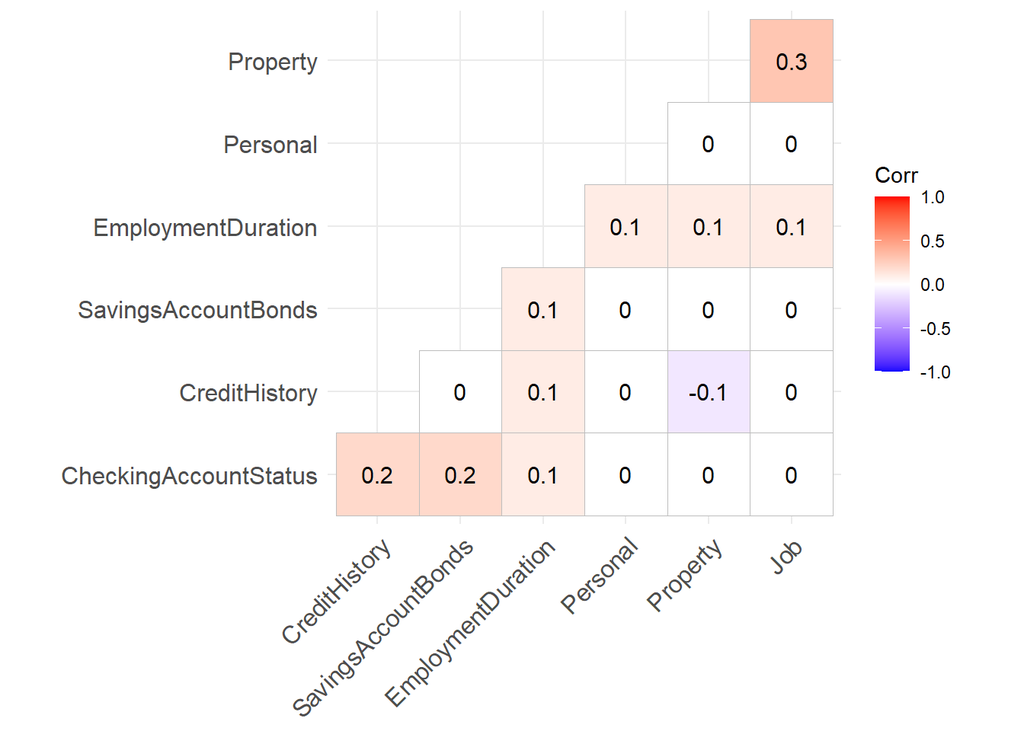

```r
germanCredit_corr <- round(cor(LCA_data), 1)
ggcorrplot(germanCredit_corr, type = "lower", lab = TRUE)
```

## Create a function to split sample into train and test using ratio

```r
set.seed(2023)

split_sample_to_train_and_test <- function(df, portion=0.7) {

  # For bootstrap samples, simple random sampling is used.
  train_indices <- createDataPartition(df$CheckingAccountStatus,
                                       p = portion,
                                       list = FALSE,
                                       times = 1)
  # create training set
  df_train <- df[train_indices, ]

  # create testing set
  df_test <- df[-train_indices, ]

  # Return multiple values as list
  return(list(df_train, df_test))
}


# split
df_split <-  split_sample_to_train_and_test(LCA_data)

# check training data set
# head(df_split[[1]][])
train_set <- df_split[[1]][]

# check testing data set
# head(df_split[[2]][])
test_set <- df_split[[2]][]
```

## Step2

Determine 2, 3,..,K class/cluster solutions. Remember to run from multiple random starts. Use AIC criterion and interpretation based on graphs to interpret LCA solutions

```r
# define function and select only the categorical variables
f<-cbind(
  CheckingAccountStatus,
  CreditHistory,
  SavingsAccountBonds,
  EmploymentDuration,
  Personal,
  Property,
  Job)~1


# created vector with 5 characters
# bic  = bayesian information criterion
# abic = adjusted bayesian information criterion
# aic  = akaike information criterion
lca_columns= c("model",
               "log_likelihood",
               "df",
               "bic",
               "abic",
               "aic",
               "likelihood_ratio",
               "r2_entropy"
               )

# pass this vector length to ncol parameter and nrow with 0
lca_results = data.frame(matrix(nrow = 0, ncol = length(lca_columns)))

# assign column names
colnames(lca_results) = lca_columns
lca_results$model<-as.integer(lca_results$model)
```

## calculate entropy R2 for poLCA model

```r
# https://gist.github.com/daob/c2b6d83815ddd57cde3cebfdc2c267b3
machine_tolerance <- sqrt(.Machine$double.eps)
entropy.R2 <- function(fit) {
  entropy <- function(p) {
    p <- p[p > machine_tolerance] # since Lim_{p->0} p log(p) = 0
    sum(-p * log(p))
  }
  error_prior <- entropy(fit$P) # Class proportions
  error_post <- mean(apply(fit$posterior, 1, entropy))
  R2_entropy <- (error_prior - error_post) / error_prior
  R2_entropy
}
```

```r
lca_row_number <- 1
for(i in 2:6){
  lca_result <- poLCA(formula = f,
                      data = train_set,
                      nclass=i, maxiter=100,
                      na.rm=FALSE,
                      nrep=10,
                      verbose=TRUE,
                      calc.se=TRUE,
                      graphs = FALSE)

  #-ve df are not acceptable model so we exit the loop
  if(lca_result$resid.df < 0){
    break
  }

  lca_results[lca_row_number,1] <- c(sprintf("Model %s", lca_row_number))
  lca_results[lca_row_number,2] <- lca_result$llik
  lca_results[lca_row_number,3] <- lca_result$resid.df
  lca_results[lca_row_number,4] <- lca_result$bic
  lca_results[lca_row_number,5] <- (-2*lca_result$llik) +
    ((log((lca_result$N + 2)/24)) * lca_result$npar)
  lca_results[lca_row_number,6] <- lca_result$aic
  lca_results[lca_row_number,7] <- lca_result$Gsq

  # calculate the Entropy (a pseudo-r-squared) for each solution
  lca_results[lca_row_number,8] <- entropy.R2(lca_result)

  lca_row_number = lca_row_number + 1
}
```

```
## Model 1: llik = -5847.165 ... best llik = -5847.165
## Model 2: llik = -5846.616 ... best llik = -5846.616
## Model 3: llik = -5854.363 ... best llik = -5846.616
## Model 4: llik = -5846.619 ... best llik = -5846.616
## Model 5: llik = -5846.642 ... best llik = -5846.616
## Model 6: llik = -5846.615 ... best llik = -5846.615
## Model 7: llik = -5854.344 ... best llik = -5846.615
## Model 8: llik = -5846.615 ... best llik = -5846.615
## Model 9: llik = -5846.616 ... best llik = -5846.615
## Model 10: llik = -5846.617 ... best llik = -5846.615
## Conditional item response (column) probabilities,
##  by outcome variable, for each class (row)
##
## $CheckingAccountStatus
##            Pr(1)  Pr(2)  Pr(3)  Pr(4)
## class 1:  0.2668 0.2472 0.0473 0.4388
## class 2:  0.2803 0.2804 0.0785 0.3608
##
## $CreditHistory
##            Pr(1)  Pr(2)  Pr(3)  Pr(4)  Pr(5)
## class 1:  0.0254 0.0493 0.4789 0.1028 0.3436
## class 2:  0.0506 0.0435 0.5743 0.0891 0.2424
##
## $SavingsAccountBonds
##            Pr(1)  Pr(2)  Pr(3)  Pr(4)  Pr(5)
## class 1:  0.5234 0.0702 0.0593 0.0398 0.3072
## class 2:  0.6341 0.1171 0.0535 0.0558 0.1395
##
## $EmploymentDuration
##            Pr(1)  Pr(2)  Pr(3)  Pr(4)  Pr(5)
## class 1:  0.1436 0.0241 0.1291 0.1869 0.5163
## class 2:  0.0000 0.2499 0.4573 0.1891 0.1037
##
## $Personal
##            Pr(1)  Pr(2)  Pr(3)  Pr(4)
## class 1:  0.0360 0.1980 0.7543 0.0117
## class 2:  0.0558 0.3925 0.4278 0.1240
##
## $Property
##            Pr(1)  Pr(2)  Pr(3)  Pr(4)
```

[output cut: 360 more lines]

```
## =========================================================
## Fit for 6 latent classes:
## =========================================================
## number of observations: 701
## number of estimated parameters: 149
## residual degrees of freedom: 552
## maximum log-likelihood: -5688.397
##
## AIC(6): 11674.79
## BIC(6): 12353.12
## G^2(6): 2597.598 (Likelihood ratio/deviance statistic)
## X^2(6): 22123.01 (Chi-square goodness of fit)
##
## ALERT: iterations finished, MAXIMUM LIKELIHOOD NOT FOUND
##
```

## convert model to numeric

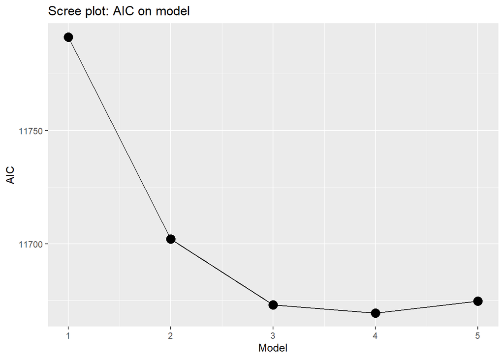

```r
model <- as.factor(lca_results$model)
lca_results$model <- as.numeric(model)

# plot the AIC
lca_results %>%
  ggplot(aes(x=model,y=aic, group=1))+
  geom_point(size=4)+
  geom_line()+
  labs(title="Scree plot: AIC on model")+
  xlab("Model")+
  ylab("AIC")
```

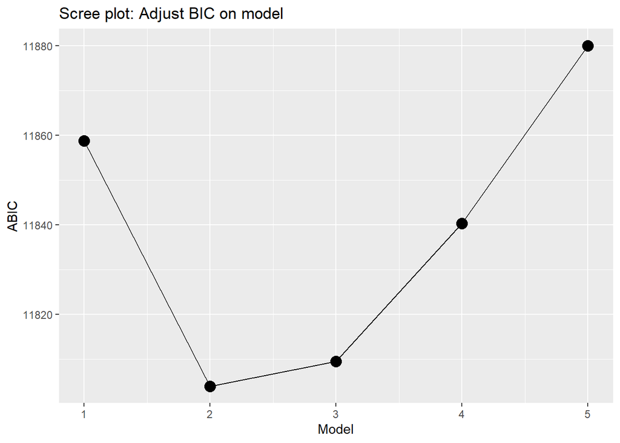

```r
# plot ABIC
lca_results %>%
  ggplot(aes(x=model,y=abic, group=1))+
  geom_point(size=4)+
  geom_line()+
  labs(title="Scree plot: Adjust BIC on model")+
  xlab("Model")+
  ylab("ABIC")
```

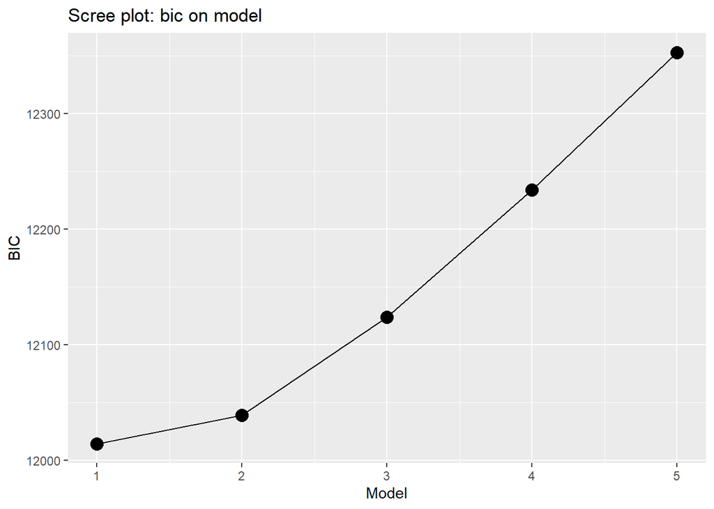

```r
# plot BIC
lca_results %>%
  ggplot(aes(x=model,y=bic, group=1))+
  geom_point(size=4)+
  geom_line()+
  labs(title="Scree plot: bic on model")+
  xlab("Model")+
  ylab("BIC")
```

# STEP 3

Perform Test validation of LCA using your chosen K. For Test, use the centers class-conditional probabilities - probs - from training set as input to probs.start for test (generated from the training set LCA solution, as the starting point for the test. Use similarity of relative class sizes and test class conditional probabilities as measures of stability.

```r
# Rerun your LCA model with the training set and your chosen K.
# Save the conditional probability
lca_result_train <- poLCA(formula = f,
                    data = train_set,
                    nclass=2, maxiter=100,
                    na.rm=FALSE,
                    nrep=10,
                    verbose=TRUE,
                    calc.se=TRUE,
                    graphs = FALSE)
```

```
## Model 1: llik = -5846.684 ... best llik = -5846.684
## Model 2: llik = -5846.615 ... best llik = -5846.615
## Model 3: llik = -5848.86 ... best llik = -5846.615
## Model 4: llik = -5854.539 ... best llik = -5846.615
## Model 5: llik = -5854.993 ... best llik = -5846.615
## Model 6: llik = -5846.627 ... best llik = -5846.615
## Model 7: llik = -5846.616 ... best llik = -5846.615
## Model 8: llik = -5854.355 ... best llik = -5846.615
## Model 9: llik = -5846.616 ... best llik = -5846.615
## Model 10: llik = -5846.616 ... best llik = -5846.615
## Conditional item response (column) probabilities,
##  by outcome variable, for each class (row)
##
## $CheckingAccountStatus
##            Pr(1)  Pr(2)  Pr(3)  Pr(4)
## class 1:  0.2803 0.2803 0.0786 0.3608
## class 2:  0.2668 0.2473 0.0472 0.4388
##
## $CreditHistory
##            Pr(1)  Pr(2)  Pr(3)  Pr(4)  Pr(5)
## class 1:  0.0506 0.0435 0.5742 0.0891 0.2425
## class 2:  0.0254 0.0493 0.4789 0.1028 0.3436
##
## $SavingsAccountBonds
##            Pr(1)  Pr(2)  Pr(3)  Pr(4)  Pr(5)
## class 1:  0.6340 0.1171 0.0535 0.0558 0.1396
## class 2:  0.5234 0.0701 0.0593 0.0398 0.3073
##
## $EmploymentDuration
##            Pr(1)  Pr(2)  Pr(3)  Pr(4)  Pr(5)
## class 1:  0.0000 0.2498 0.4572 0.1892 0.1039
## class 2:  0.1438 0.0240 0.1289 0.1868 0.5165
##
## $Personal
##            Pr(1)  Pr(2)  Pr(3)  Pr(4)
## class 1:  0.0558 0.3924 0.4279 0.1240
## class 2:  0.0360 0.1979 0.7544 0.0117
##
## $Property
##            Pr(1)  Pr(2)  Pr(3)  Pr(4)
```

[output cut: 14 more lines]

```
## =========================================================
## Fit for 2 latent classes:
## =========================================================
## number of observations: 701
## number of estimated parameters: 49
## residual degrees of freedom: 652
## maximum log-likelihood: -5846.615
##
## AIC(2): 11791.23
## BIC(2): 12014.3
## G^2(2): 2914.035 (Likelihood ratio/deviance statistic)
## X^2(2): 45970.47 (Chi-square goodness of fit)
##
## ALERT: iterations finished, MAXIMUM LIKELIHOOD NOT FOUND
##
```

```r
cond_prob <- lca_result_train$probs

# Build a new LCA model with the test set, your chosen K,
# and the probability you just saved as the initial probability.
# For example, the test model should be "poLCA(f, German.Test.Data, ...,
# prob.start = LCA.train.object$probs....)
lca_result_test <- poLCA(
  formula=f,
  data=test_set,
  nclass = 2,
  maxiter = 1000,
  graphs = FALSE,
  tol = 1e-10,
  na.rm = FALSE,
  probs.start = lca_result_train$probs,
  nrep = 10,
  verbose = TRUE,
  calc.se = TRUE
)
```

```
## Model 1: llik = -2488.404 ... best llik = -2488.404
## Model 2: llik = -2488.769 ... best llik = -2488.404
## Model 3: llik = -2488.769 ... best llik = -2488.404
## Model 4: llik = -2488.769 ... best llik = -2488.404
## Model 5: llik = -2488.404 ... best llik = -2488.404
## Model 6: llik = -2488.404 ... best llik = -2488.404
## Model 7: llik = -2488.404 ... best llik = -2488.404
## Model 8: llik = -2488.769 ... best llik = -2488.404
## Model 9: llik = -2488.769 ... best llik = -2488.404
## Model 10: llik = -2488.404 ... best llik = -2488.404
## Conditional item response (column) probabilities,
##  by outcome variable, for each class (row)
##
## $CheckingAccountStatus
##            Pr(1)  Pr(2)  Pr(3)  Pr(4)
## class 1:  0.3281 0.2870 0.0492 0.3358
## class 2:  0.2295 0.2593 0.0566 0.4545
##
## $CreditHistory
##            Pr(1)  Pr(2)  Pr(3)  Pr(4)  Pr(5)
## class 1:  0.0313 0.0430 0.7281 0.0445 0.1532
## class 2:  0.0408 0.0669 0.3494 0.0947 0.4483
##
## $SavingsAccountBonds
##            Pr(1)  Pr(2)  Pr(3)  Pr(4)  Pr(5)
## class 1:  0.7201 0.0659 0.0324 0.0716 0.1099
## class 2:  0.5569 0.1425 0.1149 0.0231 0.1626
##
## $EmploymentDuration
##            Pr(1)  Pr(2)  Pr(3)  Pr(4)  Pr(5)
## class 1:  0.0241 0.3151 0.4265 0.1426 0.0918
## class 2:  0.1267 0.0890 0.2851 0.1389 0.3602
##
## $Personal
##            Pr(1)  Pr(2)  Pr(3)  Pr(4)
## class 1:  0.0523 0.4438 0.2739 0.2300
## class 2:  0.0544 0.1688 0.7472 0.0296
##
## $Property
##            Pr(1)  Pr(2)  Pr(3)  Pr(4)
```

[output cut: 12 more lines]

```
##  0.4348 0.5652
##
## =========================================================
## Fit for 2 latent classes:
## =========================================================
## number of observations: 299
## number of estimated parameters: 49
## residual degrees of freedom: 250
## maximum log-likelihood: -2488.404
##
## AIC(2): 5074.809
## BIC(2): 5256.13
## G^2(2): 1672.989 (Likelihood ratio/deviance statistic)
## X^2(2): 27301.2 (Chi-square goodness of fit)
##
```

Print class sizes and conditional probabilities of the train model and the test model. How similar are they? Would you consider the model stable?

```r
# test model class size
lca_result_test$P
```

```
## [1] 0.4198681 0.5801319
```

```r
# test model conditional probability
lca_result_test$probs
```

```
## $CheckingAccountStatus
##               Pr(1)     Pr(2)      Pr(3)     Pr(4)
## class 1:  0.3280516 0.2869714 0.04919615 0.3357809
## class 2:  0.2295420 0.2592736 0.05663507 0.4545494
##
## $CreditHistory
##                Pr(1)      Pr(2)     Pr(3)      Pr(4)     Pr(5)
## class 1:  0.03130509 0.04300355 0.7280582 0.04445507 0.1531781
## class 2:  0.04075847 0.06688198 0.3493564 0.09465663 0.4483465
##
## $SavingsAccountBonds
##               Pr(1)      Pr(2)      Pr(3)      Pr(4)     Pr(5)
## class 1:  0.7201449 0.06594093 0.03241355 0.07158552 0.1099151
## class 2:  0.5568599 0.14252173 0.11490170 0.02313575 0.1625809
##
## $EmploymentDuration
##               Pr(1)      Pr(2)     Pr(3)     Pr(4)     Pr(5)
## class 1:  0.0240661 0.31514598 0.4264678 0.1425679 0.0917522
## class 2:  0.1267082 0.08899139 0.2851444 0.1389486 0.3602074
##
## $Personal
##                Pr(1)     Pr(2)     Pr(3)      Pr(4)
## class 1:  0.05232623 0.4438095 0.2739085 0.22995577
## class 2:  0.05436969 0.1688228 0.7472258 0.02958169
##
## $Property
##               Pr(1)     Pr(2)     Pr(3)        Pr(4)
## class 1:  0.4463314 0.2472858 0.3063829 1.181401e-84
## class 2:  0.1785277 0.2245805 0.3662904 2.306015e-01
##
## $Job
##                   Pr(1)     Pr(2)     Pr(3)      Pr(4)
## class 1:  2.166151e-215 0.2713695 0.7100440 0.01858647
## class 2:   4.035526e-02 0.1552646 0.5757005 0.22867965
```

```r
# train model class size
lca_result_train$P
```

```
## [1] 0.6328698 0.3671302
```

```r
# train model conditional probability
lca_result_train$probs
```

```
## $CheckingAccountStatus
##               Pr(1)     Pr(2)      Pr(3)     Pr(4)
## class 1:  0.2802782 0.2803341 0.07855284 0.3608348
## class 2:  0.2667755 0.2472510 0.04721310 0.4387604
##
## $CreditHistory
##                Pr(1)      Pr(2)     Pr(3)      Pr(4)     Pr(5)
## class 1:  0.05061498 0.04354348 0.5742072 0.08913152 0.2425028
## class 2:  0.02543179 0.04927875 0.4789344 0.10280431 0.3435507
##
## $SavingsAccountBonds
##               Pr(1)      Pr(2)      Pr(3)      Pr(4)    Pr(5)
## class 1:  0.6340390 0.11710041 0.05349095 0.05581565 0.139554
## class 2:  0.5234487 0.07013325 0.05933045 0.03978053 0.307307
##
## $EmploymentDuration
##                  Pr(1)      Pr(2)     Pr(3)     Pr(4)     Pr(5)
## class 1:  9.051619e-16 0.24978975 0.4571877 0.1891518 0.1038707
## class 2:  1.437685e-01 0.02402427 0.1288960 0.1868382 0.5164731
##
## $Personal
##                Pr(1)     Pr(2)     Pr(3)     Pr(4)
## class 1:  0.05575755 0.3923522 0.4279346 0.1239556
## class 2:  0.03599505 0.1979194 0.7543971 0.0116884
##
## $Property
##               Pr(1)     Pr(2)     Pr(3)      Pr(4)
## class 1:  0.3753535 0.2468154 0.3104217 0.06740933
## class 2:  0.1106532 0.2040050 0.3585817 0.32676007
##
## $Job
##                 Pr(1)      Pr(2)     Pr(3)      Pr(4)
## class 1:  0.009522269 0.29029577 0.6516055 0.04857647
## class 2:  0.041869741 0.03968274 0.5903079 0.32813965
```

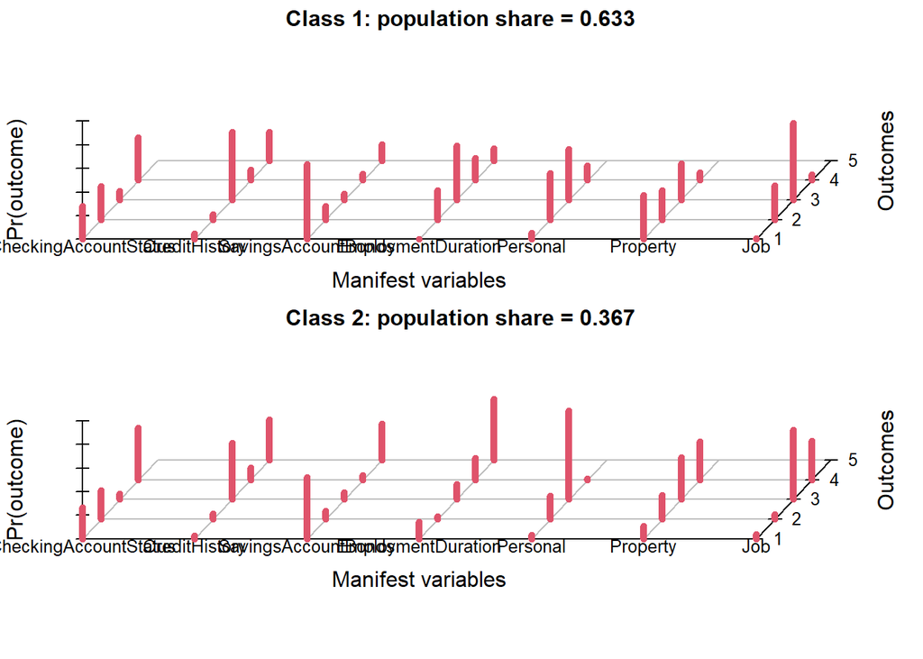

```r
# plot the two models
plot(lca_result_train)
```

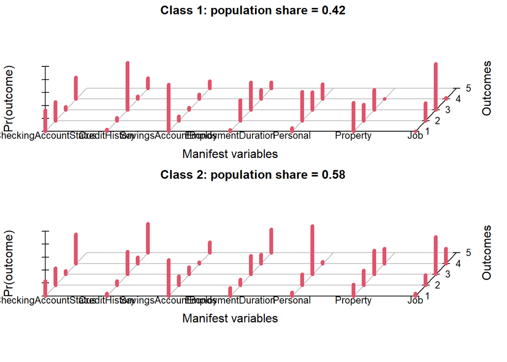

```r
plot(lca_result_test)
```

# Step 4.

```
We named the class 1 as “More Financially Secure” and the class 2 as “Less Financially Secure.”
```

# Step 5.

[output not shown]